# HEALTH INSURANCE CROSS SELL PREDICTION

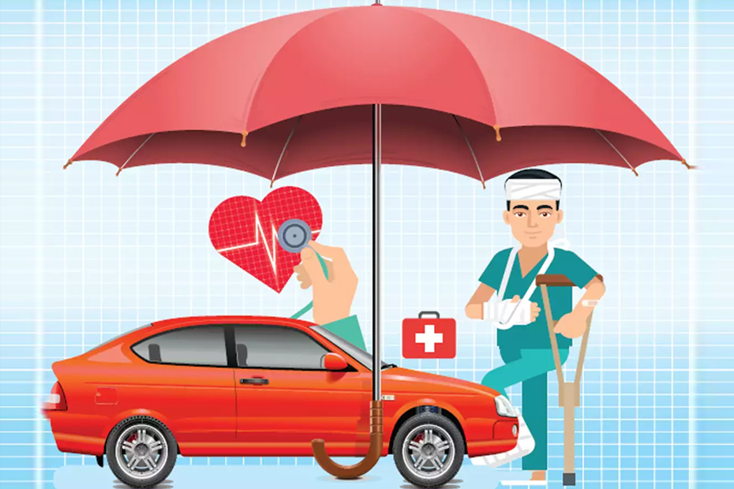

Our client is an Insurance company that has provided Health Insurance to its customers now they need your help in building a model to predict whether the policyholders (customers) from the past year will also be interested in Vehicle Insurance provided by the company.

An insurance policy is an arrangement by which a company undertakes to provide a guarantee of compensation for specified loss, damage, illness, or death in return for the payment of a specified premium. A premium is a sum of money that the customer needs to pay regularly to an insurance company for this guarantee.

For example, you may pay a premium of Rs. 5000 each year for a health insurance cover of Rs. 200,000/- so that if God forbid, you fall ill and need to be hospitalized in that year, the insurance provider company will bear the cost of hospitalization, etc. for up to Rs. 200,000. Now if you are wondering how can the company bear such high hospitalization costs when it charges a premium of only Rs. 5000/-, that is where the concept of probabilities comes into the picture. For example, like you, there may be 100 customers who would be paying a premium of Rs. 5000 every year, but only a few of them (say 2-3) would get hospitalized that year, and not everyone. This way everyone shares the risk of everyone else.

Just like medical insurance, there is vehicle insurance where every year customer needs to pay a premium of a certain amount to insurance provider company so that in case of unfortunate accident by the vehicle, the insurance provider company will provide compensation (called ‘sum assured’) to the customer.

Building a model to predict whether a customer would be interested in Vehicle Insurance is extremely helpful for the company because it can then accordingly plan its communication strategy to reach out to those customers and optimize its business model and revenue.

Now, in order to predict, whether the customer would be interested in Vehicle insurance, you have information about demographics (gender, age, region code type), Vehicles (Vehicle Age, Damage), Policy (Premium, sourcing channel), etc.

## Data Description

**id:** Unique ID for the customer

**Gender:** Gender of the customer

**Age:** Age of the customer

**Driving_License 0 :** Customer does not have DL, **1 :** Customer already has DL

**Region_Code:** Unique code for the region of the customer

**Previously_Insured 1 :** Customer already has Vehicle Insurance, **0 :** Customer doesn't have Vehicle Insurance

**Vehicle_Age:** Age of the Vehicle

**Vehicle_Damage 1 :** Customer got his/her vehicle damaged in the past. **0 :** Customer didn't get his/her vehicle damaged in the past.

**Annual_Premium:** The amount customer needs to pay as premium in the year

**PolicySalesChannel:** Anonymized Code for the channel of outreaching to the customer ie. Different Agents, Over Mail, Over Phone, In Person, etc.

**Vintage:** Number of Days, Customer has been associated with the company

**Response 1 :** Customer is interested, **0 :** Customer is not interested

### Import Libraries

```python
import numpy as np
import pandas as pd
import seaborn as sns
from matplotlib import pyplot as plt
from sklearn.metrics import accuracy_score, classification_report, confusion_matrix
from sklearn.model_selection import train_test_split
from sklearn.preprocessing import MinMaxScaler, LabelEncoder, StandardScaler, RobustScaler
from xgboost import XGBClassifier, plot_importance
from sklearn.model_selection import GridSearchCV
import warnings
warnings.filterwarnings('ignore')
```

### Import Dataset

```python
train=pd.read_csv('train.csv')
test=pd.read_csv('test.csv')
sub = pd.read_csv('sample_submission.csv')
```

```python
train.head()
```

|  | id | Gender | Age | Driving_License | Region_Code | Previously_Insured | Vehicle_Age | Vehicle_Damage | Annual_Premium | Policy_Sales_Channel | Vintage | Response |
| --- | --- | --- | --- | --- | --- | --- | --- | --- | --- | --- | --- | --- |
| 0 | 1 | Male | 44 | 1 | 28.0 | 0 | > 2 Years | Yes | 40454.0 | 26.0 | 217 | 1 |
| 1 | 2 | Male | 76 | 1 | 3.0 | 0 | 1-2 Year | No | 33536.0 | 26.0 | 183 | 0 |
| 2 | 3 | Male | 47 | 1 | 28.0 | 0 | > 2 Years | Yes | 38294.0 | 26.0 | 27 | 1 |
| 3 | 4 | Male | 21 | 1 | 11.0 | 1 | < 1 Year | No | 28619.0 | 152.0 | 203 | 0 |
| 4 | 5 | Female | 29 | 1 | 41.0 | 1 | < 1 Year | No | 27496.0 | 152.0 | 39 | 0 |

```python
test.head()
```

|  | id | Gender | Age | Driving_License | Region_Code | Previously_Insured | Vehicle_Age | Vehicle_Damage | Annual_Premium | Policy_Sales_Channel | Vintage |
| --- | --- | --- | --- | --- | --- | --- | --- | --- | --- | --- | --- |
| 0 | 381110 | Male | 25 | 1 | 11.0 | 1 | < 1 Year | No | 35786.0 | 152.0 | 53 |
| 1 | 381111 | Male | 40 | 1 | 28.0 | 0 | 1-2 Year | Yes | 33762.0 | 7.0 | 111 |
| 2 | 381112 | Male | 47 | 1 | 28.0 | 0 | 1-2 Year | Yes | 40050.0 | 124.0 | 199 |
| 3 | 381113 | Male | 24 | 1 | 27.0 | 1 | < 1 Year | Yes | 37356.0 | 152.0 | 187 |
| 4 | 381114 | Male | 27 | 1 | 28.0 | 1 | < 1 Year | No | 59097.0 | 152.0 | 297 |

```python
train.shape
```

```
(381109, 12)
```

### Checking null values in data

```python
train.isnull().sum()
```

```
id                      0
Gender                  0
Age                     0
Driving_License         0
Region_Code             0
Previously_Insured      0
Vehicle_Age             0
Vehicle_Damage          0
Annual_Premium          0
Policy_Sales_Channel    0
Vintage                 0
Response                0
dtype: int64
```

*Hence proved, there is no missing data in out train data.*

### Check Columns (Categorical or Numeric)

### It gives the names of categorical, numerical, and categorical but cardinal variables in the data set.

Note: Categorical variables with numerical appearance are also included in categorical variables.

```python
def grab_col_names(dataframe, cat_th=10, car_th=20):


    # cat_cols, cat_but_car
    cat_cols = [col for col in dataframe.columns if dataframe[col].dtypes == "O"]
    num_but_cat = [col for col in dataframe.columns if dataframe[col].nunique() < cat_th and
                   dataframe[col].dtypes != "O"]
    cat_but_car = [col for col in dataframe.columns if dataframe[col].nunique() > car_th and
                   dataframe[col].dtypes == "O"]
    cat_cols = cat_cols + num_but_cat
    cat_cols = [col for col in cat_cols if col not in cat_but_car]

    # num_cols
    num_cols = [col for col in dataframe.columns if dataframe[col].dtypes != "O"]
    num_cols = [col for col in num_cols if col not in num_but_cat]

    print(f"Observations: {dataframe.shape[0]}")
    print(f"Variables: {dataframe.shape[1]}")
    print(f'cat_cols: {len(cat_cols)}')
    print(f'num_cols: {len(num_cols)}')
    return cat_cols, num_cols, cat_but_car

cat_cols, num_cols, cat_but_car = grab_col_names(train)
```

```
Observations: 381109
Variables: 12
cat_cols: 6
num_cols: 6
```

```python
cat_cols,num_cols
```

```
(['Gender',
  'Vehicle_Age',
  'Vehicle_Damage',
  'Driving_License',
  'Previously_Insured',
  'Response'],
 ['id',
  'Age',
  'Region_Code',
  'Annual_Premium',
  'Policy_Sales_Channel',
  'Vintage'])
```

### Removing **id & Policy_Sales_Channel** column from num_cols because these columns are not providing any useful insights for modeling

```python
num_cols = [col for col in num_cols if "id" not in col]
num_cols = [col for col in num_cols if "Policy_Sales_Channel" not in col]
```

```python
num_cols
```

```
['Age', 'Region_Code', 'Annual_Premium', 'Vintage']
```

### Plotting categorical data with ratio

```
        Gender     Ratio
Male    206089  54.07613
Female  175020  45.92387
```

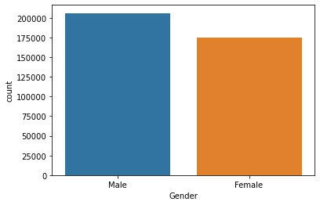

```
           Vehicle_Age      Ratio
1-2 Year        200316  52.561341
< 1 Year        164786  43.238549
> 2 Years        16007   4.200111
```

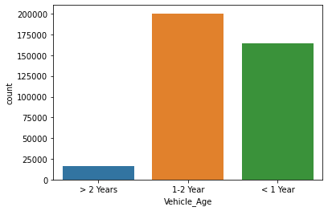

```
     Vehicle_Damage      Ratio
Yes          192413  50.487656
No           188696  49.512344
```

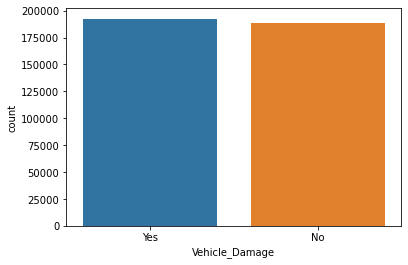

```
   Driving_License      Ratio
1           380297  99.786938
0              812   0.213062
```

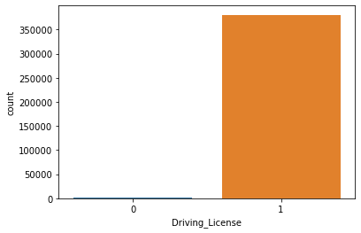

```
   Previously_Insured      Ratio
0              206481  54.178988
1              174628  45.821012
```

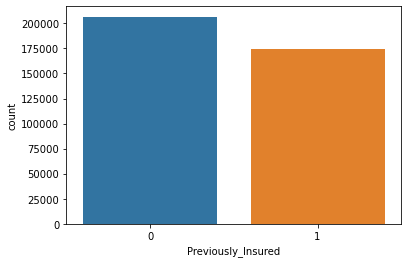

```
   Response      Ratio
0    334399  87.743664
1     46710  12.256336
```

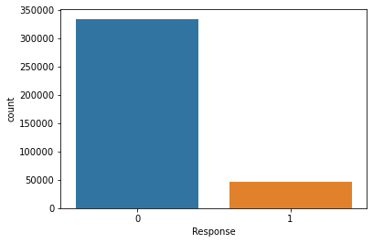

```python
def cat_summary(dataframe, col_name, plot=False):
    print(pd.DataFrame({col_name: dataframe[col_name].value_counts(),
                        "Ratio": 100 * dataframe[col_name].value_counts() / len(dataframe)}))
    if plot:
        sns.countplot(x=dataframe[col_name], data=dataframe)
        plt.show()

for i in cat_cols:
    cat_summary(train, i, plot=True)
```

### Checking numerical columns for data distribution to check it data is skewed or having outlier

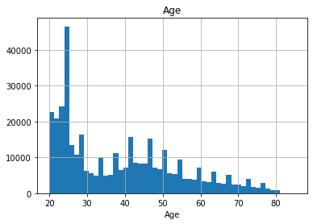

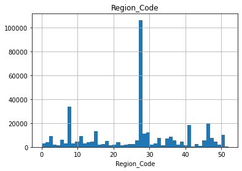

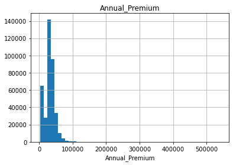

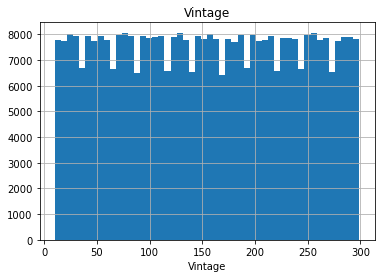

```python
def num_summary(dataframe, numerical_col, plot=False):
    quantiles = [0.05, 0.10, 0.20, 0.30, 0.40, 0.50, 0.60, 0.70, 0.80, 0.90, 0.95, 0.99]
#     print(dataframe[numerical_col].describe(quantiles).T)

    if plot:
        dataframe[numerical_col].hist(bins=50)
        plt.xlabel(numerical_col)
        plt.title(numerical_col)
        plt.show()

#     print("#####################################")

for col in num_cols:
    num_summary(train, col, plot=True)
```

### Getting mean data for all numerical columns

```python
def target_summary_with_num(dataframe, target, numerical_col):
    print(dataframe.groupby(target).agg({numerical_col: "mean"}), end="\n\n\n")

for col in num_cols:
    target_summary_with_num(train, "Response", col)
```

```
                Age
Response
0         38.178227
1         43.435560


          Region_Code
Response
0           26.336544
1           26.762963


          Annual_Premium
Response
0           30419.160276
1           31604.092742


             Vintage
Response
0         154.380243
1         154.112246
```

### Polting box plot for all numerical columns to for outlier checking

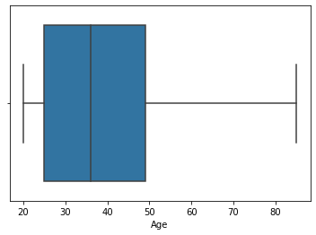

```python
sns.boxplot(x=train["Age"]);
```

### As per Annual Premium distribution we can see outliers, but we can't use normal quantile range to remove those because these are not actual outliers and can help us in modeling. Therefore, will set Q1 to 0.05 and Q3 to 0.95

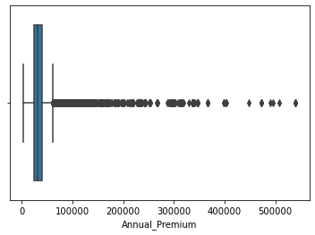

```python
sns.boxplot(x=train["Annual_Premium"]);
```

### There is no outlier in vintage

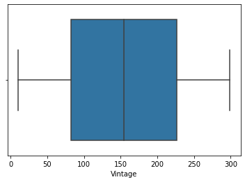

```python
sns.boxplot(x=train["Vintage"]);
```

### Gender-Response Visualization

### To understand insurance ratio for each gender, countplot is givien below

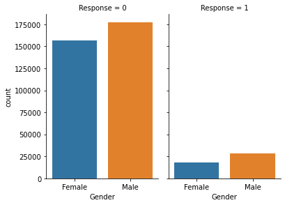

```python
df=train.groupby(['Gender','Response'])['id'].count().to_frame().rename(columns={'id':'count'}).reset_index()
g = sns.catplot(x="Gender", y="count",col="Response",
                data=df, kind="bar",
                height=4, aspect=.7);
```

### Driving license-Gender Visualization

### Gender male is more dominant in insurance policy

```python
df=train.groupby(['Gender'])['Driving_License'].count().to_frame().reset_index()
df
```

|  | Gender | Driving_License |
| --- | --- | --- |
| 0 | Female | 175020 |
| 1 | Male | 206089 |

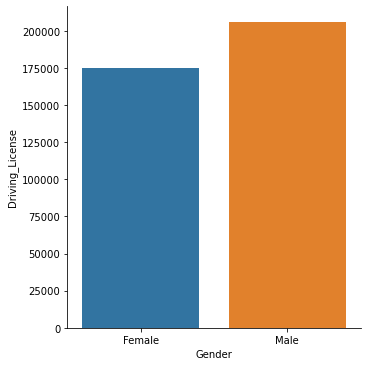

```python
sns.catplot(x="Gender", y="Driving_License",
                data=df, kind="bar");
```

### Response-Vehicle age Visualization

### Further diging into data came to know more people opt for insuranc who's vehicle age is between 1-2 years

```python
df=train.groupby(['Vehicle_Age','Response'])['id'].count().to_frame().rename(columns={'id':'count'}).reset_index()
df
```

|  | Vehicle_Age | Response | count |
| --- | --- | --- | --- |
| 0 | 1-2 Year | 0 | 165510 |
| 1 | 1-2 Year | 1 | 34806 |
| 2 | < 1 Year | 0 | 157584 |
| 3 | < 1 Year | 1 | 7202 |
| 4 | > 2 Years | 0 | 11305 |
| 5 | > 2 Years | 1 | 4702 |

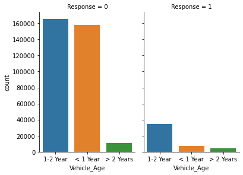

```python
g = sns.catplot(x="Vehicle_Age", y="count", col="Response",
                data=df, kind="bar",
                height=4, aspect=.7);
```

### Damage Vehicle-Response Visualization

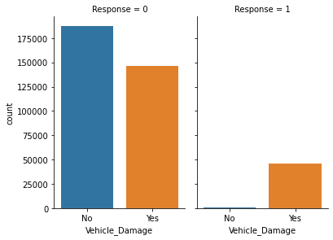

```python
df=train.groupby(['Vehicle_Damage','Response'])['id'].count().to_frame().rename(columns={'id':'count'}).reset_index()
g = sns.catplot(x="Vehicle_Damage", y="count",col="Response",
                data=df, kind="bar",
                height=4, aspect=.7);
```

# DATA PREPROCESSING

## OUTLIERS

### Data distribution is used to find outlier, as per out visualisation insights not much data points are out of range.

```python
def outlier_thresholds(dataframe, col_name, q1=0.05, q3=0.95):
    quartile1 = dataframe[col_name].quantile(q1)
    quartile3 = dataframe[col_name].quantile(q3)
    interquantile_range = quartile3 - quartile1
    up_limit = quartile3 + 3 * interquantile_range
    low_limit = quartile1 - 3 * interquantile_range
    return low_limit, up_limit


def check_outlier(dataframe, col_name):
    low_limit, up_limit = outlier_thresholds(dataframe, col_name)
    if dataframe[(dataframe[col_name] > up_limit) | (dataframe[col_name] < low_limit)].any(axis=None):
        return True
    else:
        return False

for col in num_cols:
    print(f"{col} : {check_outlier(train,col)}")
```

```
Age : False
Region_Code : False
Annual_Premium : True
Vintage : False
```

### Method below will return data points which are out of Inter Quartile Range

```python
def grab_outliers(dataframe, col_name, index=False):
    low, up = outlier_thresholds(dataframe, col_name)
    print("\n===========", col_name,"==========")
    if dataframe[((dataframe[col_name] < low) | (dataframe[col_name] > up))].shape[0] > 10:
        print(dataframe[((dataframe[col_name] < low) | (dataframe[col_name] > up))].head())
    else:
        print(dataframe[((dataframe[col_name] < low) | (dataframe[col_name] > up))])

    if index:
        outlier_index = dataframe[((dataframe[col_name] < low) | (dataframe[col_name] > up))].index
        return outlier_index

for col in num_cols:
    grab_outliers(train, col)
```

```
=========== Age ==========
Empty DataFrame
Columns: [id, Gender, Age, Driving_License, Region_Code, Previously_Insured, Vehicle_Age, Vehicle_Damage, Annual_Premium, Policy_Sales_Channel, Vintage, Response]
Index: []

=========== Region_Code ==========
Empty DataFrame
Columns: [id, Gender, Age, Driving_License, Region_Code, Previously_Insured, Vehicle_Age, Vehicle_Damage, Annual_Premium, Policy_Sales_Channel, Vintage, Response]
Index: []

=========== Annual_Premium ==========
          id  Gender  Age  Driving_License  Region_Code  Previously_Insured  \
1412    1413  Female   41                1         28.0                   0
11319  11320  Female   50                1         46.0                   1
13426  13427  Female   47                1         28.0                   0
15024  15025  Female   32                1         28.0                   0
25532  25533    Male   50                1         28.0                   0

      Vehicle_Age Vehicle_Damage  Annual_Premium  Policy_Sales_Channel  \
1412     1-2 Year            Yes        267698.0                 124.0
11319    1-2 Year             No        508073.0                  26.0
13426    1-2 Year            Yes        301762.0                 124.0
15024    1-2 Year            Yes        315565.0                 155.0
25532    1-2 Year            Yes        229935.0                 122.0

       Vintage  Response
1412        63         1
11319      192         0
13426       22         0
15024      150         0
25532       64         1

=========== Vintage ==========
Empty DataFrame
Columns: [id, Gender, Age, Driving_License, Region_Code, Previously_Insured, Vehicle_Age, Vehicle_Damage, Annual_Premium, Policy_Sales_Channel, Vintage, Response]
Index: []
```

### Removing out of range outlier and printing columns name

```python
def replace_with_thresholds(dataframe, variable):
    low_limit, up_limit = outlier_thresholds(dataframe, variable)
    dataframe.loc[(dataframe[variable] < low_limit), variable] = low_limit
    dataframe.loc[(dataframe[variable] > up_limit), variable] = up_limit

for col in num_cols:
    replace_with_thresholds(train, col)

for col in num_cols:
    print(f"{col} : {check_outlier(train,col)}")
```

```
Age : False
Region_Code : False
Annual_Premium : False
Vintage : False
```

## CORRELATION ANALYSIS

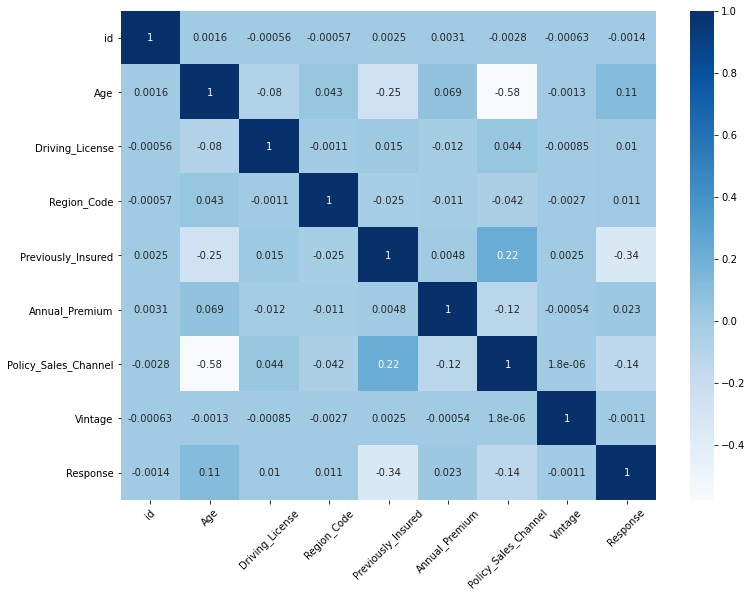

```python
df.corrwith(train["Response"]).sort_values(ascending=False)
corr_df = train.corr()
plt.figure(figsize=(12, 9))
sns.heatmap(corr_df, annot=True, xticklabels=corr_df.columns, yticklabels=corr_df.columns, cmap="Blues");
plt.xticks(rotation=45);
```

## FEATURE ENGINEERING

```python
# train['Gender'] = train['Gender'].map( {'Female': 0, 'Male': 1} ).astype(int)
```

```python
train=pd.get_dummies(train,drop_first=True)
train = train.rename(columns={'Gender_Male':'Gender'})
```

```python
train
```

|  | id | Age | Driving_License | Region_Code | Previously_Insured | Annual_Premium | Policy_Sales_Channel | Vintage | Response | Gender | Vehicle_Age_< 1 Year | Vehicle_Age_> 2 Years | Vehicle_Damage_Yes |
| --- | --- | --- | --- | --- | --- | --- | --- | --- | --- | --- | --- | --- | --- |
| 0 | 1 | 44.0 | 1 | 28.0 | 0 | 40454.0 | 26.0 | 217.0 | 1 | 1 | 0 | 1 | 1 |
| 1 | 2 | 76.0 | 1 | 3.0 | 0 | 33536.0 | 26.0 | 183.0 | 0 | 1 | 0 | 0 | 0 |
| 2 | 3 | 47.0 | 1 | 28.0 | 0 | 38294.0 | 26.0 | 27.0 | 1 | 1 | 0 | 1 | 1 |
| 3 | 4 | 21.0 | 1 | 11.0 | 1 | 28619.0 | 152.0 | 203.0 | 0 | 1 | 1 | 0 | 0 |
| 4 | 5 | 29.0 | 1 | 41.0 | 1 | 27496.0 | 152.0 | 39.0 | 0 | 0 | 1 | 0 | 0 |
| ... | ... | ... | ... | ... | ... | ... | ... | ... | ... | ... | ... | ... | ... |
| 381104 | 381105 | 74.0 | 1 | 26.0 | 1 | 30170.0 | 26.0 | 88.0 | 0 | 1 | 0 | 0 | 0 |
| 381105 | 381106 | 30.0 | 1 | 37.0 | 1 | 40016.0 | 152.0 | 131.0 | 0 | 1 | 1 | 0 | 0 |
| 381106 | 381107 | 21.0 | 1 | 30.0 | 1 | 35118.0 | 160.0 | 161.0 | 0 | 1 | 1 | 0 | 0 |
| 381107 | 381108 | 68.0 | 1 | 14.0 | 0 | 44617.0 | 124.0 | 74.0 | 0 | 0 | 0 | 1 | 1 |
| 381108 | 381109 | 46.0 | 1 | 29.0 | 0 | 41777.0 | 26.0 | 237.0 | 0 | 1 | 0 | 0 | 0 |

381109 rows × 13 columns

### Column rename and data type value change to integer

```python
train=train.rename(columns={"Vehicle_Age_< 1 Year": "Vehicle_Age_lt_1_Year", "Vehicle_Age_> 2 Years": "Vehicle_Age_gt_2_Years"})
train['Vehicle_Age_lt_1_Year']=train['Vehicle_Age_lt_1_Year'].astype('int')
train['Vehicle_Age_gt_2_Years']=train['Vehicle_Age_gt_2_Years'].astype('int')
train['Vehicle_Damage_Yes']=train['Vehicle_Damage_Yes'].astype('int')
```

```python
train["premium_age_ratio"] = train["Annual_Premium"]/train["Age"]
```

```python
train["premium_vintage_ratio"] = train["Annual_Premium"]/train["Vintage"]
```

```python
train
```

|  | id | Age | Driving_License | Region_Code | Previously_Insured | Annual_Premium | Policy_Sales_Channel | Vintage | Response | Gender | Vehicle_Age_lt_1_Year | Vehicle_Age_gt_2_Years | Vehicle_Damage_Yes | premium_age_ratio | premium_vintage_ratio |
| --- | --- | --- | --- | --- | --- | --- | --- | --- | --- | --- | --- | --- | --- | --- | --- |
| 0 | 1 | 44.0 | 1 | 28.0 | 0 | 40454.0 | 26.0 | 217.0 | 1 | 1 | 0 | 1 | 1 | 919.409091 | 186.423963 |
| 1 | 2 | 76.0 | 1 | 3.0 | 0 | 33536.0 | 26.0 | 183.0 | 0 | 1 | 0 | 0 | 0 | 441.263158 | 183.256831 |
| 2 | 3 | 47.0 | 1 | 28.0 | 0 | 38294.0 | 26.0 | 27.0 | 1 | 1 | 0 | 1 | 1 | 814.765957 | 1418.296296 |
| 3 | 4 | 21.0 | 1 | 11.0 | 1 | 28619.0 | 152.0 | 203.0 | 0 | 1 | 1 | 0 | 0 | 1362.809524 | 140.980296 |
| 4 | 5 | 29.0 | 1 | 41.0 | 1 | 27496.0 | 152.0 | 39.0 | 0 | 0 | 1 | 0 | 0 | 948.137931 | 705.025641 |
| ... | ... | ... | ... | ... | ... | ... | ... | ... | ... | ... | ... | ... | ... | ... | ... |
| 381104 | 381105 | 74.0 | 1 | 26.0 | 1 | 30170.0 | 26.0 | 88.0 | 0 | 1 | 0 | 0 | 0 | 407.702703 | 342.840909 |
| 381105 | 381106 | 30.0 | 1 | 37.0 | 1 | 40016.0 | 152.0 | 131.0 | 0 | 1 | 1 | 0 | 0 | 1333.866667 | 305.465649 |
| 381106 | 381107 | 21.0 | 1 | 30.0 | 1 | 35118.0 | 160.0 | 161.0 | 0 | 1 | 1 | 0 | 0 | 1672.285714 | 218.124224 |
| 381107 | 381108 | 68.0 | 1 | 14.0 | 0 | 44617.0 | 124.0 | 74.0 | 0 | 0 | 0 | 1 | 1 | 656.132353 | 602.932432 |
| 381108 | 381109 | 46.0 | 1 | 29.0 | 0 | 41777.0 | 26.0 | 237.0 | 0 | 1 | 0 | 0 | 0 | 908.195652 | 176.274262 |

381109 rows × 15 columns

```python
num_feat = ['Age','Vintage','premium_age_ratio','premium_vintage_ratio']
ss = StandardScaler()
train[num_feat] = ss.fit_transform(train[num_feat])
```

### Normalizing data between 0 and 1

```python
mm = MinMaxScaler()
train[['Annual_Premium']] = mm.fit_transform(train[['Annual_Premium']])
train=train.drop('id',axis=1)
```

```python
cat_feat = ['Gender', 'Driving_License', 'Previously_Insured', 'Vehicle_Age_lt_1_Year','Vehicle_Age_gt_2_Years','Vehicle_Damage_Yes']
for column in cat_feat:
    train[column] = train[column].astype('str')
```

### Applying the same processes to the Test Data

```python
# test['Gender'] = test['Gender'].map( {'Female': 0, 'Male': 1} ).astype(int)
test=pd.get_dummies(test,drop_first=True)
test = test.rename(columns={'Gender_Male':'Gender'})
test=test.rename(columns={"Vehicle_Age_< 1 Year": "Vehicle_Age_lt_1_Year", "Vehicle_Age_> 2 Years": "Vehicle_Age_gt_2_Years"})
test['Vehicle_Age_lt_1_Year']=test['Vehicle_Age_lt_1_Year'].astype('int')
test['Vehicle_Age_gt_2_Years']=test['Vehicle_Age_gt_2_Years'].astype('int')
test['Vehicle_Damage_Yes']=test['Vehicle_Damage_Yes'].astype('int')
test["premium_age_ratio"] = test["Annual_Premium"]/test["Age"]
test["premium_vintage_ratio"] = test["Annual_Premium"]/test["Vintage"]
test=test.drop('id',axis=1)
```

```python
ss = StandardScaler()
test[num_feat] = ss.fit_transform(test[num_feat])


mm = MinMaxScaler()
test[['Annual_Premium']] = mm.fit_transform(test[['Annual_Premium']])
```

```python
for column in cat_feat:
    test[column] = test[column].astype('str')
```

# Data Modeling

## XGBOOST Classifier

```python
X_train, Y_train = train.drop("Response",axis = 1), train["Response"]
```

```python
X_train.head()
```

|  | Age | Driving_License | Region_Code | Previously_Insured | Annual_Premium | Policy_Sales_Channel | Vintage | Gender | Vehicle_Age_lt_1_Year | Vehicle_Age_gt_2_Years | Vehicle_Damage_Yes | premium_age_ratio | premium_vintage_ratio |
| --- | --- | --- | --- | --- | --- | --- | --- | --- | --- | --- | --- | --- | --- |
| 0 | 0.333777 | 1 | 28.0 | 0 | 0.179957 | 26.0 | 0.748795 | 1 | 0 | 1 | 1 | 0.023841 | -0.327306 |
| 1 | 2.396751 | 1 | 3.0 | 0 | 0.147043 | 26.0 | 0.342443 | 1 | 0 | 0 | 0 | -0.783760 | -0.333165 |
| 2 | 0.527181 | 1 | 28.0 | 0 | 0.169680 | 26.0 | -1.521998 | 1 | 0 | 1 | 1 | -0.152904 | 1.951662 |
| 3 | -1.148985 | 1 | 11.0 | 1 | 0.123649 | 152.0 | 0.581474 | 1 | 1 | 0 | 0 | 0.772756 | -0.411377 |
| 4 | -0.633242 | 1 | 41.0 | 1 | 0.118306 | 152.0 | -1.378580 | 0 | 1 | 0 | 0 | 0.072365 | 0.632109 |

```python
Y_train
```

```
0         1
1         0
2         1
3         0
4         0
         ..
381104    0
381105    0
381106    0
381107    0
381108    0
Name: Response, Length: 381109, dtype: int64
```

### Setting columns data type as integer to prevent for discrepency

```python
for column in cat_feat:
    X_train[column] = X_train[column].astype('int')
    test[column] = test[column].astype('int')

for column in num_feat:
    X_train[column] = X_train[column].astype('int')
    test[column] = test[column].astype('int')
```

### Training Xgboost model

```python
from xgboost import XGBClassifier, plot_importance

# fit model no training data
model = XGBClassifier(eval_metric='mlogloss')
model.fit(X_train, Y_train)

predictions = model.predict(test)
predictions = [round(value) for value in predictions]
```

### Testing model on reference data

```python
test = pd.DataFrame()
test['Response'] = sub['Response']
test["Pred_Response"] = predictions
```

```python
test
```

|  | Response | Pred_Response |
| --- | --- | --- |
| 0 | 0 | 0 |
| 1 | 0 | 0 |
| 2 | 0 | 0 |
| 3 | 0 | 0 |
| 4 | 0 | 0 |
| ... | ... | ... |
| 127032 | 0 | 0 |
| 127033 | 0 | 0 |
| 127034 | 0 | 0 |
| 127035 | 0 | 0 |
| 127036 | 0 | 0 |

127037 rows × 2 columns

```python
### Checking Model Accuracy
```

```python
accuracy = accuracy_score(test['Response'].values, test['Pred_Response'].values)
print("Accuracy: %.2f%%" % (accuracy * 100.0))
```

```
Accuracy: 99.68%
```